# RDA project

JBNU statistics

2021 11 12

## 목적 : 단동 비닐하우스 환기율 및 온습도에 대한 예측모형 구축 및 평가

## 사용모형 : Multiple Linear Regression Model v.s Artificial Neural Network Model (ANN)

## 1. Loading data (내부기온 반응변수)

- 작물있음 데이터에서 외부CO2의 값이 결측치인 경우는 제외하였음.

```r
setwd("D:/OneDrive - 전북대학교/전북대학교/농림과학원용역/2021")
plantyes <- read.csv("작물있음.csv",sep=",",header=T)
plantyes <- plantyes[is.na(plantyes$외부CO2)==FALSE,]
head(plantyes,10)
```

```
##    외부기온 내부기온 내외부기온차 외부상대습도 내부상대습도 내외부상대습도차
## 1      22.9     31.1          8.3         78.7         55.0             23.7
## 2      22.8     29.7          6.9         77.1         58.7             18.4
## 3      23.3     29.7          6.4         75.5         58.4             17.1
## 4      23.6     29.8          6.2         72.9         57.8             15.1
## 5      24.0     30.0          6.0         71.2         56.4             14.8
## 6      25.1     33.3          8.1         66.6         49.6             17.0
## 7      25.9     35.6          9.7         66.0         43.6             22.4
## 8      25.0     34.0          8.9         68.0         44.9             23.1
## 9      25.9     33.7          7.8         65.6         46.4             19.2
## 10     26.8     35.9          9.1         61.8         44.1             17.7
##    외부CO2 내부CO2 내외부CO2차 외부풍속 외부일사량 환기율 환기창면적 작물유무
## 1    469.5   462.0         7.5    1.398      372.7    5.4       0.15      yes
## 2    464.5   459.7         4.8    1.326      309.9    5.0       0.15      yes
## 3    457.5   451.3         6.2    0.835      291.9    4.0       0.15      yes
```

[output cut: 18 more lines]

```r
plantyes$작물유무 <- as.factor(plantyes$작물유무)
plantno <- read.csv("작물없음.csv",sep=",",header=T)
head(plantno,10)
```

```
##    외부기온 내부기온 내외부기온차 외부상대습도 내부상대습도 내외부상대습도차
## 1      16.8     27.1         10.3         45.1         39.6              5.5
## 2      17.2     28.3         11.1         42.5         37.6              4.9
## 3      17.6     29.1         11.5         42.9         33.2              9.7
## 4      18.0     30.3         12.4         41.2         32.4              8.8
## 5      17.9     30.6         12.7         37.2         28.8              8.4
## 6      18.0     31.3         13.3         37.4         27.1             10.3
## 7      18.0     31.7         13.7         35.8         25.3             10.5
## 8      18.0     32.0         14.0         38.6         24.4             14.2
## 9      18.3     32.7         14.5         37.0         23.5             13.5
## 10     18.3     32.6         14.3         36.1         22.6             13.5
##    외부CO2 내부CO2 내외부CO2차 외부풍속 외부일사량 환기율 환기창면적 작물유무
## 1    543.5   608.0        64.5    1.576      409.4  0.704       0.04       no
## 2    543.0   580.0        37.0    1.707      442.7  0.756       0.04       no
## 3    522.5   585.5        63.0    1.342      476.5  0.634       0.04       no
```

[output cut: 18 more lines]

```r
plantno$작물유무 <- as.factor(plantno$작물유무)
plant <- rbind(plantno,plantyes)
```

```r
#library(nnet)
#library(devtools)
#library(neuralnet)
#library(NeuralNetTools)
```

## 2. 작물유무에 따라 데이터를 나누어서 분석 실시

### 2.1 작물이 없을 떄

#### Multiple Linear Regression Model

- 먼저 변수들 간의 상관관계를 파악하기 위해 상관분석을 실시한다.

```r
ex1 <- plantno[,c(2,12,1,10,11,13,14,15)]
head(ex1)
```

```
##   내부기온 환기율 외부기온 외부풍속 외부일사량 환기창면적 작물유무 작물유무수치
## 1     27.1  0.704     16.8    1.576      409.4       0.04       no            0
## 2     28.3  0.756     17.2    1.707      442.7       0.04       no            0
## 3     29.1  0.634     17.6    1.342      476.5       0.04       no            0
## 4     30.3  0.798     18.0    1.802      505.7       0.04       no            0
## 5     30.6  1.084     17.9    2.583      536.0       0.04       no            0
## 6     31.3  1.493     18.0    3.660      564.9       0.04       no            0
```

```r
ex2 <- ex1[,-7]
```

```r
cor(ex2)
```

```
##                  내부기온     환기율      외부기온      외부풍속    외부일사량
## 내부기온      1.000000000 -0.4124776  6.577626e-01 -2.917363e-03  6.287721e-01
## 환기율       -0.412477633  1.0000000  1.668245e-01  5.063954e-01  6.080400e-02
## 외부기온      0.657762568  0.1668245  1.000000e+00  3.063871e-01  3.274643e-01
## 외부풍속     -0.002917363  0.5063954  3.063871e-01  1.000000e+00  4.772916e-02
## 외부일사량    0.628772078  0.0608040  3.274643e-01  4.772916e-02  1.000000e+00
## 환기창면적   -0.510671420  0.8309530 -9.044468e-20  3.715441e-20 -5.089237e-20
## 작물유무수치           NA         NA            NA            NA            NA
##                 환기창면적 작물유무수치
## 내부기온     -5.106714e-01           NA
## 환기율        8.309530e-01           NA
## 외부기온     -9.044468e-20           NA
## 외부풍속      3.715441e-20           NA
## 외부일사량   -5.089237e-20           NA
## 환기창면적    1.000000e+00           NA
## 작물유무수치            NA            1
```

- 산점도행렬과 상관계수그림을 그리면 다음과 같다.

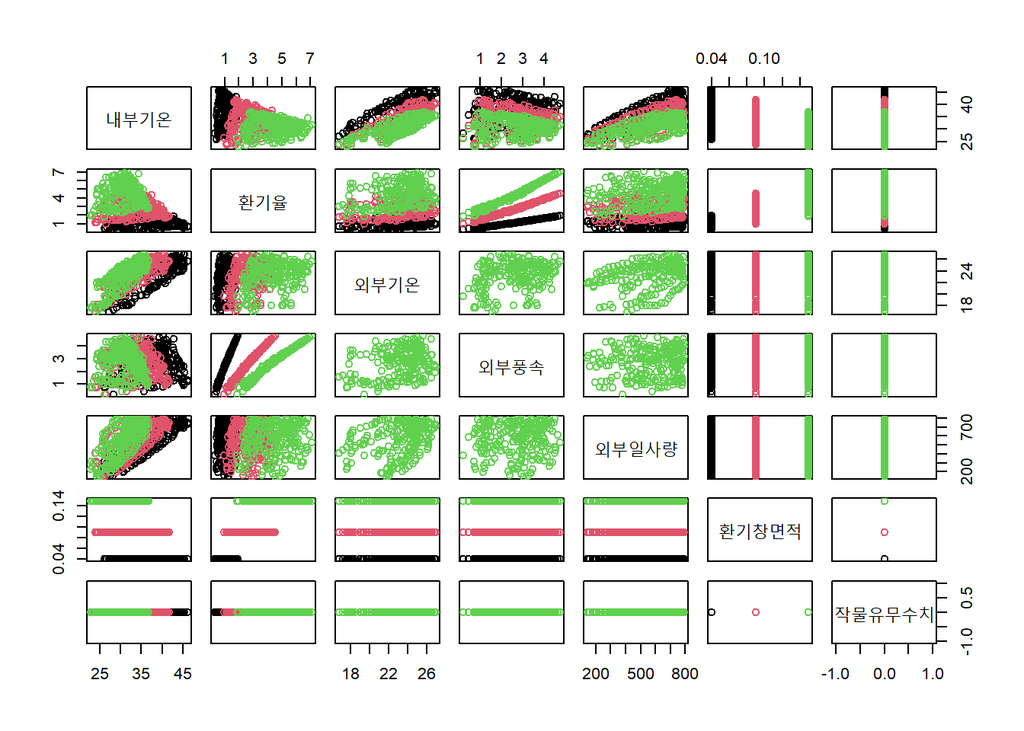

```r
pairs(ex2[1:nrow(plantno),],col=factor(ex2$환기창면적))
```

- 산점도를 통해 알 수 있는 사실은 환기율과 환기창면적이 증가할수록, 외부기온과 외부일사량이 떨어질 수록 내부기온이 내려간다는 점이다. 환기창면적과의 교호작용은 뚜렷하게 관측되는 것이 없으나, 외부풍속과의 교호작용의 존재 가능성이 추측된다. 외부풍속은 약하지만 내부기온과 음의 상관을 보이는 것으로 생각된다.

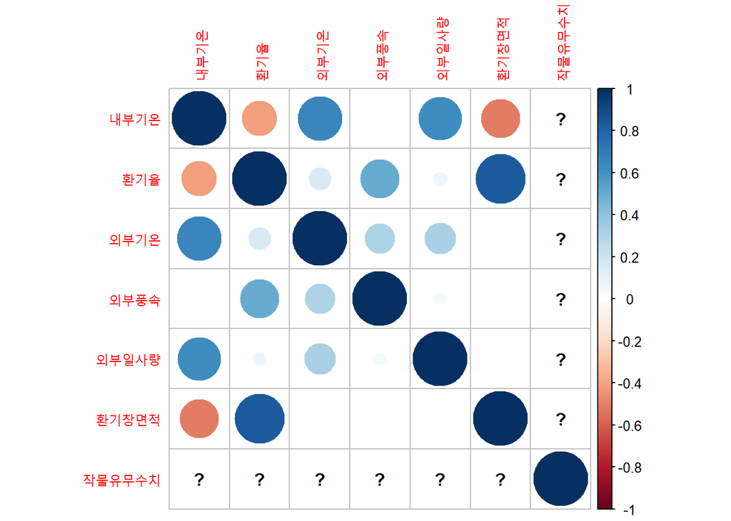

```r
library(corrplot)
corrplot(cor(ex2))
```

- 그리고 각 변수에 대한 기초통계량은 다음과 같이 계산된다.

```r
library(psych)
describe(ex1[,c(-6,-7,-8)])
```

```
##            vars   n   mean     sd median trimmed    mad    min    max  range
## 내부기온      1 735  33.96   4.99  33.80   33.86   5.04  22.70  46.20  23.50
## 환기율        2 735   2.81   1.64   2.64    2.68   1.86   0.32   7.09   6.78
## 외부기온      3 735  23.39   2.30  24.00   23.66   1.93  16.80  27.00  10.20
## 외부풍속      4 735   2.71   1.08   2.87    2.73   1.29   0.21   4.74   4.54
## 외부일사량    5 735 568.60 171.31 601.10  584.32 191.40 143.00 795.20 652.20
##             skew kurtosis   se
## 내부기온    0.18    -0.54 0.18
## 환기율      0.55    -0.67 0.06
## 외부기온   -0.98     0.30 0.08
## 외부풍속   -0.26    -0.99 0.04
## 외부일사량 -0.63    -0.61 6.32
```

- 내부기온을 반응변수로 하여 각 변수의 주효과와, 환기창면적과의 교호작용을 고려한 다중선형회귀모형을 적합하면 다음과 같다.

```r
m_no <- lm(내부기온~환기율+외부기온+외부풍속+외부일사량+환기창면적*환기율+환기창면적+환기창면적*외부기온+환기창면적*외부풍속+환기창면적*외부일사량,data=plantno)
summary(m_no)
```

```
##
## Call:
## lm(formula = 내부기온 ~ 환기율 + 외부기온 + 외부풍속 + 외부일사량 +
##     환기창면적 * 환기율 + 환기창면적 + 환기창면적 * 외부기온 +
##     환기창면적 * 외부풍속 + 환기창면적 * 외부일사량, data = plantno)
##
## Residuals:
##     Min      1Q  Median      3Q     Max
## -3.9671 -0.4896  0.0692  0.6144  2.9178
##
## Coefficients:
##                         Estimate Std. Error t value Pr(>|t|)
## (Intercept)           -1.820e+00  8.731e-01  -2.085 0.037421 *
## 환기율                 3.418e+00  3.839e-01   8.904  < 2e-16 ***
## 외부기온               1.385e+00  4.055e-02  34.148  < 2e-16 ***
## 외부풍속              -1.722e-01  9.455e-02  -1.821 0.068990 .
## 외부일사량             2.244e-02  5.191e-04  43.233  < 2e-16 ***
## 환기창면적            -1.214e+01  9.351e+00  -1.298 0.194709
## 환기율:환기창면적      1.683e+01  1.007e+00  16.708  < 2e-16 ***
## 외부기온:환기창면적   -1.529e+00  3.916e-01  -3.905 0.000103 ***
## 외부풍속:환기창면적   -5.183e+01  3.795e+00 -13.658  < 2e-16 ***
## 외부일사량:환기창면적 -1.201e-01  5.449e-03 -22.039  < 2e-16 ***
## ---
## Signif. codes:  0 '***' 0.001 '**' 0.01 '*' 0.05 '.' 0.1 ' ' 1
##
## Residual standard error: 0.9818 on 725 degrees of freedom
## Multiple R-squared:  0.9617, Adjusted R-squared:  0.9612
## F-statistic:  2024 on 9 and 725 DF,  p-value: < 2.2e-16
```

- 모형적합 결과 외부풍속과 환기창면적이 유의수준 0.05에서 유의미하지 않다. 이는 이전 모형에서 환기율이 변수에 의해 거의 완벽하게 설명되기 때문에 환기율을 제외한 다른 변수들을 모형에서 필요로 하지 않는 것으로 생각된다. 즉, 환기율만 모형에 포함시키던지 외부풍속과 환기창면적을 포함시키던지 선택이 필요할 수 있다.
- 조정된 결정계수의 값이 $R^2_{adj}=0.9612$이다.
- 외부풍속과 환기창면적을 제외한 후 모형을 적합해 보면 다음과 같다. 교호작용은 환기율을 중심으로 형성되도록 하였다.

```r
m_no <- lm(내부기온~환기율+외부기온+외부일사량+환기율*외부기온+환기율*외부일사량,data=plantno)
summary(m_no)
```

```
##
## Call:
## lm(formula = 내부기온 ~ 환기율 + 외부기온 + 외부일사량 + 환기율 *
##     외부기온 + 환기율 * 외부일사량, data = plantno)
##
## Residuals:
##     Min      1Q  Median      3Q     Max
## -3.8518 -0.9474  0.0767  0.8850  3.1444
##
## Coefficients:
##                     Estimate Std. Error t value Pr(>|t|)
## (Intercept)       -5.3905754  0.9139981  -5.898 5.64e-09 ***
## 환기율             1.1268284  0.3272898   3.443 0.000608 ***
## 외부기온           1.3607454  0.0421540  32.280  < 2e-16 ***
## 외부일사량         0.0213458  0.0005969  35.762  < 2e-16 ***
## 환기율:외부기온   -0.0498529  0.0142464  -3.499 0.000495 ***
## 환기율:외부일사량 -0.0027699  0.0001813 -15.279  < 2e-16 ***
## ---
## Signif. codes:  0 '***' 0.001 '**' 0.01 '*' 0.05 '.' 0.1 ' ' 1
##
## Residual standard error: 1.287 on 729 degrees of freedom
## Multiple R-squared:  0.9339, Adjusted R-squared:  0.9334
## F-statistic:  2059 on 5 and 729 DF,  p-value: < 2.2e-16
```

- 모든 변수가 유의하고 조정된 결정계수의 값이 $R^2_{adj}=0.9334$이다.

#### Best subset selection

- 여러 측도들을 이용하여 모형에 포함될 변수를 적절히 선택해 보도록 하겠다.

```r
library(leaps)
ms0 <- regsubsets(내부기온~환기율+외부기온+외부풍속+외부일사량+환기창면적*환기율+환기창면적+환기창면적*외부기온+환기창면적*외부풍속+환기창면적*외부일사량,data=plantno,
                     nvmax=9)
ms0.summary <- summary(ms0)
ms0.summary
```

```
## Subset selection object
## Call: regsubsets.formula(내부기온 ~ 환기율 + 외부기온 + 외부풍속 +
##     외부일사량 + 환기창면적 * 환기율 + 환기창면적 + 환기창면적 *
##     외부기온 + 환기창면적 * 외부풍속 + 환기창면적 * 외부일사량,
##     data = plantno, nvmax = 9)
## 9 Variables  (and intercept)
##                       Forced in Forced out
## 환기율                    FALSE      FALSE
## 외부기온                  FALSE      FALSE
## 외부풍속                  FALSE      FALSE
## 외부일사량                FALSE      FALSE
## 환기창면적                FALSE      FALSE
## 환기율:환기창면적         FALSE      FALSE
## 외부기온:환기창면적       FALSE      FALSE
## 외부풍속:환기창면적       FALSE      FALSE
## 외부일사량:환기창면적     FALSE      FALSE
## 1 subsets of each size up to 9
## Selection Algorithm: exhaustive
##          환기율 외부기온 외부풍속 외부일사량 환기창면적 환기율:환기창면적
## 1  ( 1 ) " "    "*"      " "      " "        " "        " "
## 2  ( 1 ) "*"    "*"      " "      " "        " "        " "
## 3  ( 1 ) " "    "*"      " "      "*"        " "        " "
## 4  ( 1 ) " "    "*"      "*"      "*"        " "        " "
## 5  ( 1 ) " "    "*"      " "      "*"        " "        "*"
## 6  ( 1 ) "*"    "*"      " "      "*"        " "        "*"
## 7  ( 1 ) "*"    "*"      " "      "*"        " "        "*"
## 8  ( 1 ) "*"    "*"      "*"      "*"        " "        "*"
## 9  ( 1 ) "*"    "*"      "*"      "*"        "*"        "*"
##          외부기온:환기창면적 외부풍속:환기창면적 외부일사량:환기창면적
## 1  ( 1 ) " "                 " "                 " "
## 2  ( 1 ) " "                 " "                 " "
## 3  ( 1 ) " "                 " "                 "*"
## 4  ( 1 ) " "                 " "                 "*"
## 5  ( 1 ) " "                 "*"                 "*"
## 6  ( 1 ) " "                 "*"                 "*"
## 7  ( 1 ) "*"                 "*"                 "*"
## 8  ( 1 ) "*"                 "*"                 "*"
## 9  ( 1 ) "*"                 "*"                 "*"
```

```r
par(mfrow=c(2,2))
# RSS=SSE
plot(ms0.summary$rss,xlab="Number of Variables",ylab="RSS",type="l")
# Adj R^2
plot(ms0.summary$adjr2,xlab="Number of Variables",ylab="Adjusted RSq",type="l")
which.max(ms0.summary$adjr2)
```

```
## [1] 9
```

```r
points(which.max(ms0.summary$adjr2)
,ms0.summary$adjr2[which.max(ms0.summary$adjr2)
], col="red",cex=2,pch=20)
# Cp
plot(ms0.summary$cp,xlab="Number of Variables",ylab="Cp",type='l')
which.min(ms0.summary$cp)
```

```
## [1] 8
```

```r
points(which.min(ms0.summary$cp)
,ms0.summary$cp[which.min(ms0.summary$cp)
],col="red",cex=2,pch=20)
# BIC
plot(ms0.summary$bic,xlab="Number of Variables",ylab="BIC",type='l')
which.min(ms0.summary$bic)
```

```
## [1] 7
```

```r
points(which.min(ms0.summary$bic)
,ms0.summary$bic[which.min(ms0.summary$bic)
],col="red",cex=2,pch=20)
```

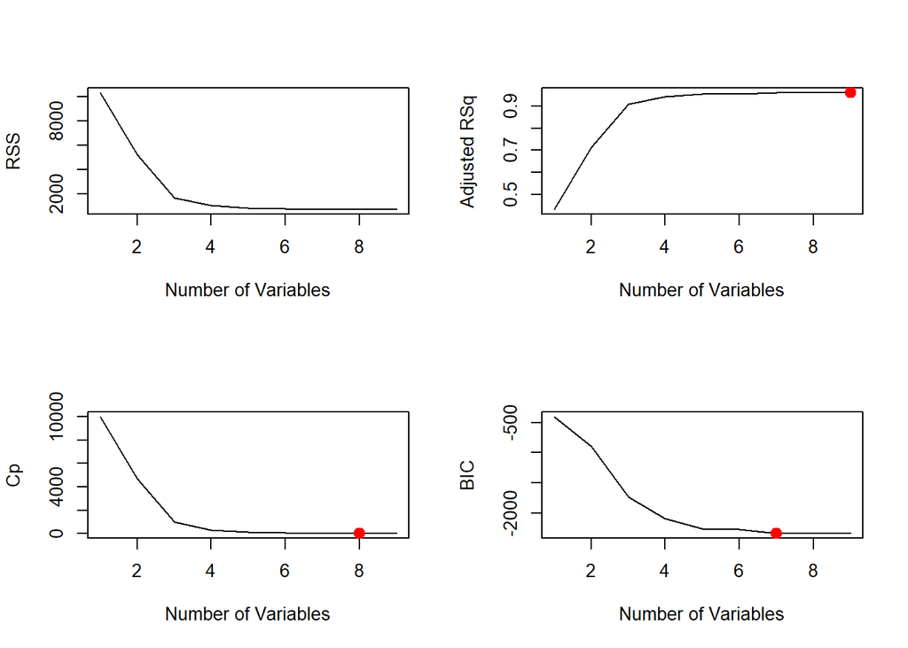

- 외부풍속과 환기창면적을 제외하는 것이 좋다는 결과이다.
- 환기창면적을 제외한 모형에 대해서 다시한번 선택해 보자.

```r
library(leaps)
ms0 <- regsubsets(내부기온~환기율+외부기온+외부풍속+외부일사량+환기율*외부풍속+환기율*외부기온+환기율*외부일사량,data=plantno,
                     nvmax=7)
ms0.summary <- summary(ms0)
ms0.summary
```

```
## Subset selection object
## Call: regsubsets.formula(내부기온 ~ 환기율 + 외부기온 + 외부풍속 +
##     외부일사량 + 환기율 * 외부풍속 + 환기율 * 외부기온 + 환기율 *
##     외부일사량, data = plantno, nvmax = 7)
## 7 Variables  (and intercept)
##                   Forced in Forced out
## 환기율                FALSE      FALSE
## 외부기온              FALSE      FALSE
## 외부풍속              FALSE      FALSE
## 외부일사량            FALSE      FALSE
## 환기율:외부풍속       FALSE      FALSE
## 환기율:외부기온       FALSE      FALSE
## 환기율:외부일사량     FALSE      FALSE
## 1 subsets of each size up to 7
## Selection Algorithm: exhaustive
##          환기율 외부기온 외부풍속 외부일사량 환기율:외부풍속 환기율:외부기온
## 1  ( 1 ) " "    "*"      " "      " "        " "             " "
## 2  ( 1 ) " "    "*"      " "      " "        " "             "*"
## 3  ( 1 ) " "    "*"      " "      "*"        " "             " "
## 4  ( 1 ) " "    "*"      " "      "*"        "*"             " "
## 5  ( 1 ) " "    "*"      " "      "*"        "*"             "*"
## 6  ( 1 ) " "    "*"      "*"      "*"        "*"             "*"
## 7  ( 1 ) "*"    "*"      "*"      "*"        "*"             "*"
##          환기율:외부일사량
## 1  ( 1 ) " "
## 2  ( 1 ) " "
## 3  ( 1 ) "*"
## 4  ( 1 ) "*"
## 5  ( 1 ) "*"
## 6  ( 1 ) "*"
## 7  ( 1 ) "*"
```

```r
par(mfrow=c(2,2))
# RSS=SSE
plot(ms0.summary$rss,xlab="Number of Variables",ylab="RSS",type="l")
# Adj R^2
plot(ms0.summary$adjr2,xlab="Number of Variables",ylab="Adjusted RSq",type="l")
which.max(ms0.summary$adjr2)
```

```
## [1] 7
```

```r
points(which.max(ms0.summary$adjr2)
,ms0.summary$adjr2[which.max(ms0.summary$adjr2)
], col="red",cex=2,pch=20)
# Cp
plot(ms0.summary$cp,xlab="Number of Variables",ylab="Cp",type='l')
which.min(ms0.summary$cp)
```

```
## [1] 7
```

```r
points(which.min(ms0.summary$cp)
,ms0.summary$cp[which.min(ms0.summary$cp)
],col="red",cex=2,pch=20)
# BIC
plot(ms0.summary$bic,xlab="Number of Variables",ylab="BIC",type='l')
which.min(ms0.summary$bic)
```

```
## [1] 6
```

```r
points(which.min(ms0.summary$bic)
,ms0.summary$bic[which.min(ms0.summary$bic)
],col="red",cex=2,pch=20)
```

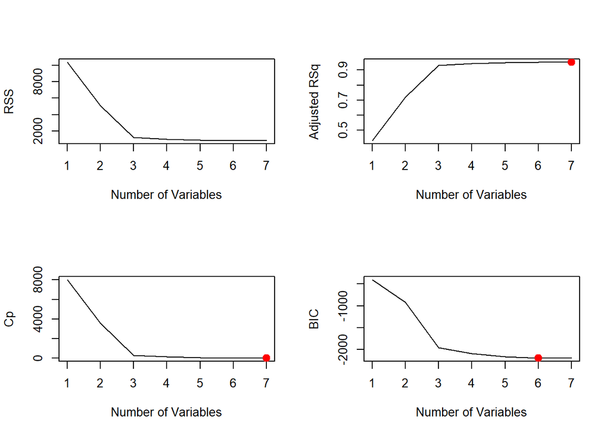

- 여전히 여러 변수를 포함한 모형을 선호하나, 3~4개변수를 가지는 경우 측도들이 안정화되는 경향이 있어 모형의 단순성을 위해서는 간단한 모형선택할 수도 있다.

#### 교차타당검증에 의한 모형 비교

- 지금부터는 train:test=7:3 으로 데이터를 나누어서 몇 개의 후보 모형들의 test RMSE를 계산하여 보겠다. 이 값이 작을수록 예측력이 우수한 모형이라고 볼 수 있다.
- 먼저 데이터를 임의로 train:test=7:3 의 비율로 나눈다. train data는 모형구축 시, test data는 구축된 모형을 평가 시 사용한다.

```r
set.seed(5790)
train.index <- sample(1:nrow(plantno), round(nrow(plantno)*7/10), replace=F)
ex1_train <- plantno[train.index,]
ex1_test <- plantno[-train.index,]
```

```r
m0 <- lm(내부기온~환기율+외부기온+외부풍속+외부일사량+환기창면적*환기율+환기창면적+환기창면적*외부기온+환기창면적*외부풍속+환기창면적*외부일사량,data=ex1_train)
y_hat0 <- predict(m0,ex1_test)
RMSE0 <- mean(sum((ex1_test$내부기온-y_hat0)^2))
RMSE0
```

```
## [1] 204.0439
```

```r
m0 <- lm(내부기온~환기율+외부기온+외부일사량+환기율*외부기온+환기율*외부일사량,data=ex1_train)
y_hat0 <- predict(m0,ex1_test)
RMSE1 <- mean(sum((ex1_test$내부기온-y_hat0)^2))
RMSE1
```

```
## [1] 359.6834
```

```r
m0 <- lm(내부기온~환기율+외부기온+외부풍속+외부일사량+환기율*외부풍속+환기율*외부기온+환기율*외부일사량,data=ex1_train)
y_hat0 <- predict(m0,ex1_test)
RMSE2 <- mean(sum((ex1_test$내부기온-y_hat0)^2))
RMSE2
```

```
## [1] 240.2506
```

```r
m0 <- lm(내부기온~외부기온+외부풍속+외부일사량+환기창면적+환기창면적*외부일사량,data=ex1_train)
y_hat0 <- predict(m0,ex1_test)
RMSE3 <- mean(sum((ex1_test$내부기온-y_hat0)^2))
RMSE3
```

```
## [1] 297.228
```

- 결과적으로 4가지 모형들 중 모든 변수를 포함한 모형이 가장 우수하였다.
- 환기창면적을 제거하였을 때 두번째로 우수하였다.

```r
summary(lm(내부기온~환기율+외부기온+외부풍속+외부일사량+환기창면적*환기율+환기창면적+환기창면적*외부기온+환기창면적*외부풍속+환기창면적*외부일사량,data=plantno) )
```

```
##
## Call:
## lm(formula = 내부기온 ~ 환기율 + 외부기온 + 외부풍속 + 외부일사량 +
##     환기창면적 * 환기율 + 환기창면적 + 환기창면적 * 외부기온 +
##     환기창면적 * 외부풍속 + 환기창면적 * 외부일사량, data = plantno)
##
## Residuals:
##     Min      1Q  Median      3Q     Max
## -3.9671 -0.4896  0.0692  0.6144  2.9178
##
## Coefficients:
##                         Estimate Std. Error t value Pr(>|t|)
## (Intercept)           -1.820e+00  8.731e-01  -2.085 0.037421 *
## 환기율                 3.418e+00  3.839e-01   8.904  < 2e-16 ***
## 외부기온               1.385e+00  4.055e-02  34.148  < 2e-16 ***
## 외부풍속              -1.722e-01  9.455e-02  -1.821 0.068990 .
## 외부일사량             2.244e-02  5.191e-04  43.233  < 2e-16 ***
## 환기창면적            -1.214e+01  9.351e+00  -1.298 0.194709
## 환기율:환기창면적      1.683e+01  1.007e+00  16.708  < 2e-16 ***
## 외부기온:환기창면적   -1.529e+00  3.916e-01  -3.905 0.000103 ***
## 외부풍속:환기창면적   -5.183e+01  3.795e+00 -13.658  < 2e-16 ***
## 외부일사량:환기창면적 -1.201e-01  5.449e-03 -22.039  < 2e-16 ***
## ---
## Signif. codes:  0 '***' 0.001 '**' 0.01 '*' 0.05 '.' 0.1 ' ' 1
##
## Residual standard error: 0.9818 on 725 degrees of freedom
## Multiple R-squared:  0.9617, Adjusted R-squared:  0.9612
## F-statistic:  2024 on 9 and 725 DF,  p-value: < 2.2e-16
```

```r
summary( lm(내부기온~환기율+외부기온+외부풍속+외부일사량+환기율*외부풍속+환기율*외부기온+환기율*외부일사량,data=plantno) )
```

```
##
## Call:
## lm(formula = 내부기온 ~ 환기율 + 외부기온 + 외부풍속 + 외부일사량 +
##     환기율 * 외부풍속 + 환기율 * 외부기온 + 환기율 * 외부일사량,
##     data = plantno)
##
## Residuals:
##     Min      1Q  Median      3Q     Max
## -3.5333 -0.6749  0.0856  0.7120  2.9711
##
## Coefficients:
##                     Estimate Std. Error t value Pr(>|t|)
## (Intercept)       -5.1407888  0.7856985  -6.543 1.14e-10 ***
## 환기율             0.4644235  0.2821944   1.646      0.1
## 외부기온           1.4320075  0.0386708  37.031  < 2e-16 ***
## 외부풍속          -0.4977594  0.0785525  -6.337 4.12e-10 ***
## 외부일사량         0.0213839  0.0005064  42.229  < 2e-16 ***
## 환기율:외부풍속    0.3883871  0.0270428  14.362  < 2e-16 ***
## 환기율:외부기온   -0.0809160  0.0126319  -6.406 2.69e-10 ***
## 환기율:외부일사량 -0.0027512  0.0001535 -17.927  < 2e-16 ***
## ---
## Signif. codes:  0 '***' 0.001 '**' 0.01 '*' 0.05 '.' 0.1 ' ' 1
##
## Residual standard error: 1.088 on 727 degrees of freedom
## Multiple R-squared:  0.9528, Adjusted R-squared:  0.9524
## F-statistic:  2098 on 7 and 727 DF,  p-value: < 2.2e-16
```

### 2.1 작물이 있을 떄

#### Multiple Linear Regression Model

- 먼저 변수들 간의 상관관계를 파악하기 위해 상관분석을 실시한다.

```r
ex1 <- plantyes[,c(2,12,1,10,11,13,14,15)]
head(ex1)
```

```
##   내부기온 환기율 외부기온 외부풍속 외부일사량 환기창면적 작물유무 작물유무수치
## 1     31.1    5.4     22.9    1.398      372.7       0.15      yes            1
## 2     29.7    5.0     22.8    1.326      309.9       0.15      yes            1
## 3     29.7    4.0     23.3    0.835      291.9       0.15      yes            1
## 4     29.8    4.2     23.6    0.943      297.5       0.15      yes            1
## 5     30.0    5.2     24.0    1.481      335.4       0.15      yes            1
## 6     33.3    4.9     25.1    1.132      549.7       0.15      yes            1
```

```r
ex2 <- ex1[,-7]
```

```r
cor(ex2)
```

```
##                내부기온      환기율    외부기온    외부풍속  외부일사량
## 내부기온      1.0000000 -0.18254940  0.77533900 -0.10014625  0.77862921
## 환기율       -0.1825494  1.00000000  0.04996941  0.76546935  0.10313855
## 외부기온      0.7753390  0.04996941  1.00000000  0.12445561  0.47323743
## 외부풍속     -0.1001462  0.76546935  0.12445561  1.00000000  0.01247939
## 외부일사량    0.7786292  0.10313855  0.47323743  0.01247939  1.00000000
## 환기창면적   -0.3339927  0.67141924 -0.08617862  0.10718424 -0.01979362
## 작물유무수치         NA          NA          NA          NA          NA
##               환기창면적 작물유무수치
## 내부기온     -0.33399269           NA
## 환기율        0.67141924           NA
## 외부기온     -0.08617862           NA
## 외부풍속      0.10718424           NA
## 외부일사량   -0.01979362           NA
## 환기창면적    1.00000000           NA
## 작물유무수치          NA            1
```

- 산점도행렬과 상관계수그림을 그리면 다음과 같다.

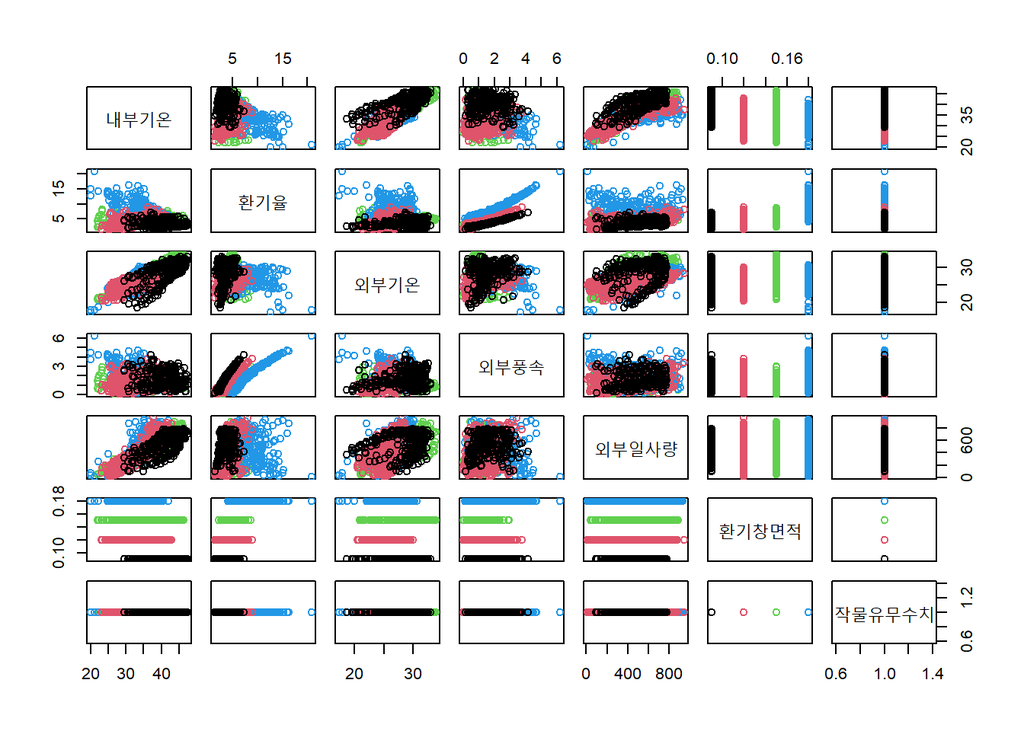

```r
pairs(ex2[1:nrow(plantyes),],col=factor(ex2$환기창면적))
```

- 작물이 없을 때와 유사하다.

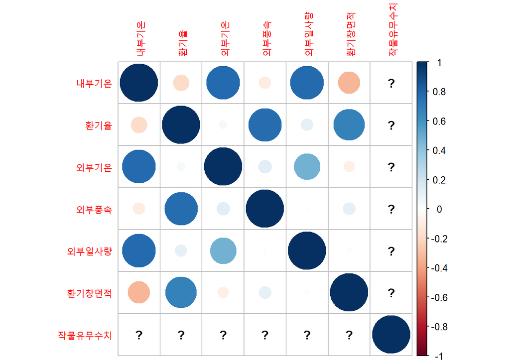

```r
library(corrplot)
corrplot(cor(ex2))
```

- 그리고 각 변수에 대한 기초통계량은 다음과 같이 계산된다. 이 결과에 의하면 5가지 변수들 중 외부일사량이 가장 변동이 크다고 할 수 있다.

```r
library(psych)
describe(ex1[,c(-6,-7)])
```

```
##              vars    n   mean     sd median trimmed    mad   min    max  range
## 내부기온        1 1055  35.43   5.69   35.4   35.47   5.93 20.00  47.40  27.40
## 환기율          2 1055   5.15   2.58    4.6    4.77   2.08  1.40  20.90  19.50
## 외부기온        3 1055  26.91   2.99   26.9   26.94   3.26 17.30  33.90  16.60
## 외부풍속        4 1055   1.50   0.92    1.3    1.41   0.83  0.00   6.22   6.21
## 외부일사량      5 1055 459.27 225.19  459.2  460.76 275.02 10.04 950.00 939.96
## 작물유무수치    6 1055   1.00   0.00    1.0    1.00   0.00  1.00   1.00   0.00
##               skew kurtosis   se
## 내부기온     -0.08    -0.63 0.18
## 환기율        1.62     3.44 0.08
## 외부기온     -0.12    -0.42 0.09
## 외부풍속      0.97     0.80 0.03
## 외부일사량   -0.02    -1.02 6.93
## 작물유무수치   NaN      NaN 0.00
```

```r
m_yes <- lm(내부기온~환기율+외부기온+외부풍속+외부일사량+환기창면적*환기율+환기창면적+환기창면적*외부기온+환기창면적*외부풍속+환기창면적*외부일사량,data=plantyes)
summary(m_yes)
```

```
##
## Call:
## lm(formula = 내부기온 ~ 환기율 + 외부기온 + 외부풍속 + 외부일사량 +
##     환기창면적 * 환기율 + 환기창면적 + 환기창면적 * 외부기온 +
##     환기창면적 * 외부풍속 + 환기창면적 * 외부일사량, data = plantyes)
##
## Residuals:
##     Min      1Q  Median      3Q     Max
## -3.9682 -0.8398  0.0584  0.9029  3.7663
##
## Coefficients:
##                         Estimate Std. Error t value Pr(>|t|)
## (Intercept)            1.387e+01  1.736e+00   7.991 3.52e-15 ***
## 환기율                 1.374e+00  2.300e-01   5.972 3.21e-09 ***
## 외부기온               7.759e-01  6.165e-02  12.586  < 2e-16 ***
## 외부풍속               4.606e-02  3.461e-01   0.133    0.894
## 외부일사량             2.470e-02  8.323e-04  29.676  < 2e-16 ***
## 환기창면적            -1.064e+02  1.335e+01  -7.976 3.94e-15 ***
## 환기율:환기창면적      5.791e+00  1.207e+00   4.797 1.85e-06 ***
## 외부기온:환기창면적    1.932e+00  4.667e-01   4.139 3.77e-05 ***
## 외부풍속:환기창면적   -3.890e+01  2.767e+00 -14.056  < 2e-16 ***
## 외부일사량:환기창면적 -1.110e-01  6.019e-03 -18.444  < 2e-16 ***
## ---
## Signif. codes:  0 '***' 0.001 '**' 0.01 '*' 0.05 '.' 0.1 ' ' 1
##
## Residual standard error: 1.248 on 1045 degrees of freedom
## Multiple R-squared:  0.9523, Adjusted R-squared:  0.9519
## F-statistic:  2318 on 9 and 1045 DF,  p-value: < 2.2e-16
```

- 모형적합 결과 외부풍속이 유의수준 0.05에서 유의미하지 않았다. 조정된 결정계수의 값이 $R^2_{adj}=0.9519$이므로 작물이 없을 때와 비슷한 수준이다.

#### Best subset selection

- 여러 측도들을 이용하여 모형에 포함될 변수를 적절히 선택해 보도록 하겠다.

```r
library(leaps)
ms0 <- regsubsets(내부기온~환기율+외부기온+외부풍속+외부일사량+환기창면적*환기율+환기창면적+환기창면적*외부기온+환기창면적*외부풍속+환기창면적*외부일사량,data=plantyes,
                     nvmax=9)
ms0.summary <- summary(ms0)
ms0.summary
```

```
## Subset selection object
## Call: regsubsets.formula(내부기온 ~ 환기율 + 외부기온 + 외부풍속 +
##     외부일사량 + 환기창면적 * 환기율 + 환기창면적 + 환기창면적 *
##     외부기온 + 환기창면적 * 외부풍속 + 환기창면적 * 외부일사량,
##     data = plantyes, nvmax = 9)
## 9 Variables  (and intercept)
##                       Forced in Forced out
## 환기율                    FALSE      FALSE
## 외부기온                  FALSE      FALSE
## 외부풍속                  FALSE      FALSE
## 외부일사량                FALSE      FALSE
## 환기창면적                FALSE      FALSE
## 환기율:환기창면적         FALSE      FALSE
## 외부기온:환기창면적       FALSE      FALSE
## 외부풍속:환기창면적       FALSE      FALSE
## 외부일사량:환기창면적     FALSE      FALSE
## 1 subsets of each size up to 9
## Selection Algorithm: exhaustive
##          환기율 외부기온 외부풍속 외부일사량 환기창면적 환기율:환기창면적
## 1  ( 1 ) " "    " "      " "      "*"        " "        " "
## 2  ( 1 ) " "    "*"      " "      "*"        " "        " "
## 3  ( 1 ) " "    "*"      " "      "*"        " "        " "
## 4  ( 1 ) " "    "*"      "*"      "*"        " "        " "
## 5  ( 1 ) "*"    "*"      " "      "*"        " "        " "
## 6  ( 1 ) " "    "*"      " "      "*"        "*"        "*"
## 7  ( 1 ) "*"    "*"      " "      "*"        "*"        "*"
## 8  ( 1 ) "*"    "*"      " "      "*"        "*"        "*"
## 9  ( 1 ) "*"    "*"      "*"      "*"        "*"        "*"
##          외부기온:환기창면적 외부풍속:환기창면적 외부일사량:환기창면적
## 1  ( 1 ) " "                 " "                 " "
## 2  ( 1 ) " "                 " "                 " "
## 3  ( 1 ) " "                 " "                 "*"
## 4  ( 1 ) " "                 " "                 "*"
## 5  ( 1 ) " "                 "*"                 "*"
## 6  ( 1 ) " "                 "*"                 "*"
## 7  ( 1 ) " "                 "*"                 "*"
## 8  ( 1 ) "*"                 "*"                 "*"
## 9  ( 1 ) "*"                 "*"                 "*"
```

```r
par(mfrow=c(2,2))
# RSS=SSE
plot(ms0.summary$rss,xlab="Number of Variables",ylab="RSS",type="l")
# Adj R^2
plot(ms0.summary$adjr2,xlab="Number of Variables",ylab="Adjusted RSq",type="l")
which.max(ms0.summary$adjr2)
```

```
## [1] 8
```

```r
points(which.max(ms0.summary$adjr2)
,ms0.summary$adjr2[which.max(ms0.summary$adjr2)
], col="red",cex=2,pch=20)
# Cp
plot(ms0.summary$cp,xlab="Number of Variables",ylab="Cp",type='l')
which.min(ms0.summary$cp)
```

```
## [1] 8
```

```r
points(which.min(ms0.summary$cp)
,ms0.summary$cp[which.min(ms0.summary$cp)
],col="red",cex=2,pch=20)
# BIC
plot(ms0.summary$bic,xlab="Number of Variables",ylab="BIC",type='l')
which.min(ms0.summary$bic)
```

```
## [1] 8
```

```r
points(which.min(ms0.summary$bic)
,ms0.summary$bic[which.min(ms0.summary$bic)
],col="red",cex=2,pch=20)
```

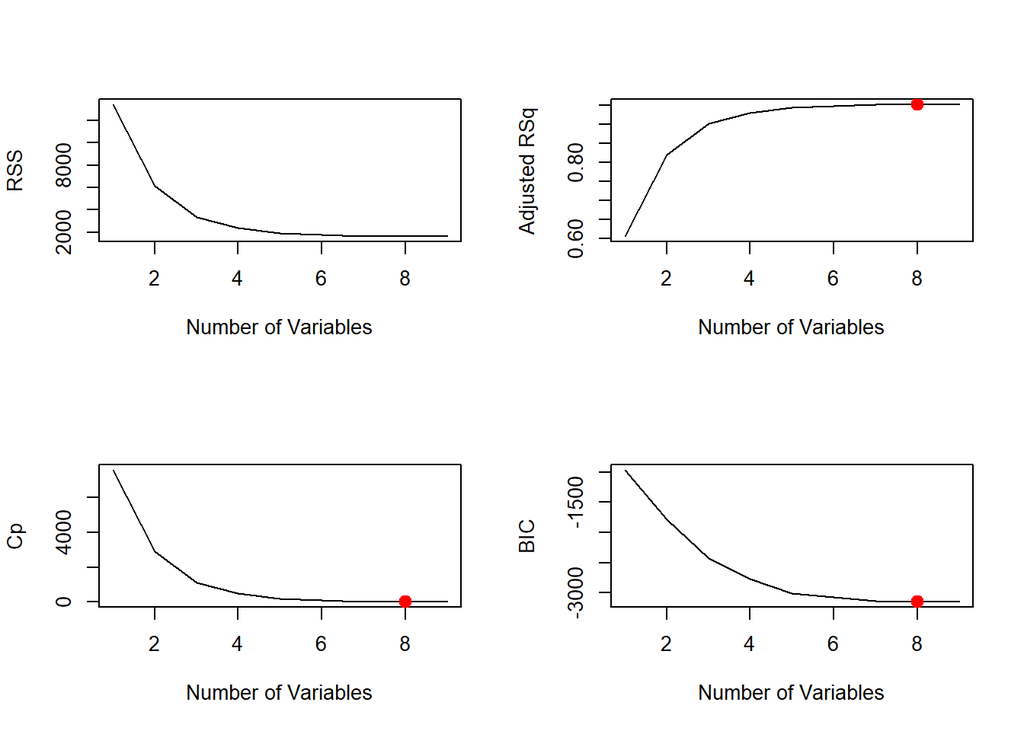

#### 교차타당검증에 의한 모형 비교

- 지금부터는 train:test=7:3 으로 데이터를 나누어서 몇 개의 후보 모형들의 test RMSE를 계산하여 보겠다. 이 값이 작을수록 예측력이 우수한 모형이라고 볼 수 있다.
- 먼저 데이터를 임의로 train:test=7:3 의 비율로 나눈다. train data는 모형구축 시, test data는 구축된 모형을 평가 시 사용한다.

```r
set.seed(5790)
train.index <- sample(1:nrow(plantyes), round(nrow(plantyes)*7/10), replace=F)
ex1_train <- plantyes[train.index,]
ex1_test <- plantyes[-train.index,]
```

```r
m0 <- lm(내부기온~환기율+외부기온+외부풍속+외부일사량+환기창면적*환기율+환기창면적+환기창면적*외부기온+환기창면적*외부풍속+환기창면적*외부일사량,data=ex1_train)
y_hat0 <- predict(m0,ex1_test)
RMSE0 <- mean(sum((ex1_test$내부기온-y_hat0)^2))
RMSE0
```

```
## [1] 485.0244
```

```r
m0 <- lm(내부기온~환기율+외부기온+외부일사량+환기창면적*환기율+환기창면적+환기창면적*외부기온+환기창면적:외부풍속+환기창면적*외부일사량,data=ex1_train)
y_hat0 <- predict(m0,ex1_test)
RMSE0 <- mean(sum((ex1_test$내부기온-y_hat0)^2))
RMSE0
```

```
## [1] 484.3281
```

```r
m0 <- lm(내부기온~환기율+외부기온+외부풍속+외부일사량+환기창면적*환기율+환기창면적+환기창면적*외부풍속+환기창면적*외부일사량,data=ex1_train)
y_hat0 <- predict(m0,ex1_test)
RMSE0 <- mean(sum((ex1_test$내부기온-y_hat0)^2))
RMSE0
```

```
## [1] 500.7967
```

```r
m0 <- lm(내부기온~외부기온+외부일사량+환기창면적:환기율+환기창면적+환기창면적:외부풍속+환기창면적*외부일사량,data=ex1_train)
y_hat0 <- predict(m0,ex1_test)
RMSE0 <- mean(sum((ex1_test$내부기온-y_hat0)^2))
RMSE0
```

```
## [1] 518.4329
```